# Activity in Pectoral Sandpipers: Statistics and figures

## Combined figure: Mating success and behaviour

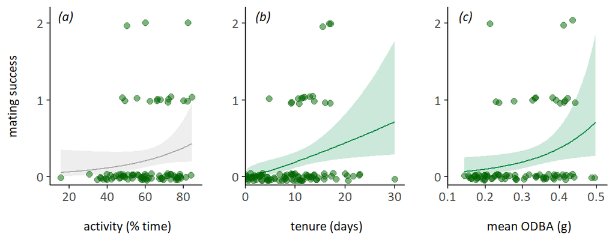

```r
fig3 <- success_active_plot +
  success_tenure_plot + ylab("\n") +
  success_odba_plot + ylab("\n") +
  plot_layout(nrow = 1,
              widths=c(1,1.05,1.05),
              heights=c(1))+
  plot_annotation(tag_levels = 'a',
                  tag_prefix = '(',
                  tag_suffix = ')') &
  theme(plot.tag = element_text(size=label.size, family = font.family, face="italic"),
        plot.tag.position = c(.3, .96))

fig3
```

```r
if(save_plots==TRUE){
ggsave(plot=fig3,
       filename='figure3-beh-mating-success.jpg',
       path=output_path,
       width=16,
       height=7,
       units="cm",
       dpi=300)
}
```

## Combined supplementary figure: Reproductive success and behaviour

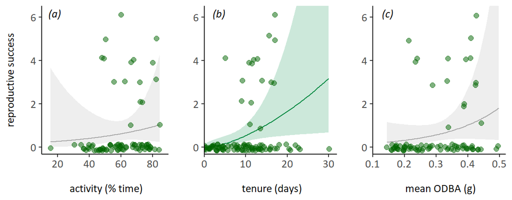

```r
supfigsuccess <- egg_active_plot +
  egg_tenure_plot + ylab("\n") +
  egg_odba_plot + ylab("\n") +
  plot_layout(nrow = 1,
              widths=c(1,1.05,1.05),
              heights=c(1))+
  plot_annotation(tag_levels = 'a',
                  tag_prefix = '(',
                  tag_suffix = ')') &
  theme(plot.tag = element_text(size=label.size, family = font.family, face="italic"),
        plot.tag.position = c(.3, .96))

supfigsuccess
```

```r
if(save_plots==TRUE){
ggsave(plot=supfigsuccess,
       filename='figure-rsuccess.jpg',
       path=output_path,
       width=16,
       height=7,
       units="cm",
       dpi=300)
}
```

```r
rm(m1_active_eff, m1_active_eff2, m1_effects, m1_effects2, m1_tenure_eff,
   m2_active_eff, m2_effects, m2_tenure_eff,
   m3_active_eff, m3_effects, m3_tenure_eff,
   m4_active_eff, m4_effects, m4_tenure_eff,
   success_m1, success_m1_flex,
   success_m2, success_m2_flex,
   success_m3, success_m3_flex,
   success_m4, success_m4_flex,
   success_mt, success_mt_flex)
```

# Q: Does activity relative to competitors predict success at a given nest?

For this analysis, we don’t want to limit the dataset just to males with at least 2 days of data.

But we do want to exclude nests that were depredated before genotyping.

We adjust the dataset accordingly.

Median daily distance from the nest site tended to be within 200 metres (in 14/18 cases).

```r
nest_male_date_sub <- nest_male_date %>%
  filter(!nest %in% predated_nests$nest) %>%
  mutate(dist_m=as.numeric(dist_m),
         success=as.integer(success)) %>%
  select(nest, date, bird_ID, colour_combo, mean_ODBA, prop_activity, dist_m, success) %>%
  filter(dist_m <= 200) %>%
  group_by(date, nest) %>%
  mutate(z_prop_act = scale(prop_activity),
         z_ODBA = scale(mean_ODBA)) %>%
  filter(!is.na(z_prop_act)) %>%
  as.data.frame()
```

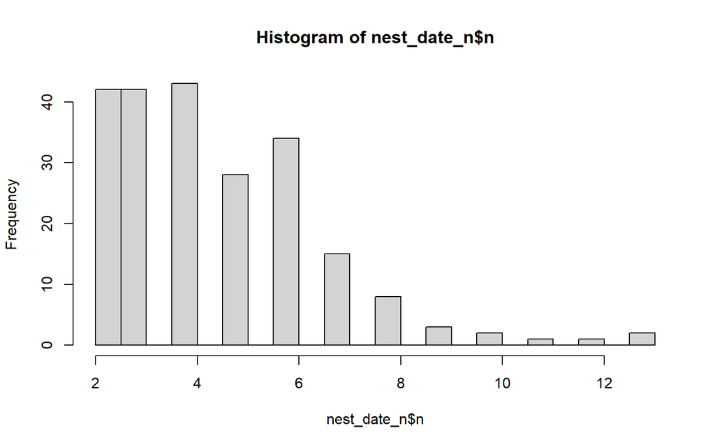

```r
nest_date_n <- nest_male_date_sub %>%
  group_by(nest, date) %>%
  summarise(n=n()) %>%
  arrange(n)

hist(nest_date_n$n, breaks=20)
```

Median sample size (number of rival males per nest per day):

```r
median(nest_date_n$n)
```

```
## [1] 4
```

Mean sample size:

```r
mean(nest_date_n$n)
```

```
## [1] 4.48
```

Standard deviation:

```r
sd(nest_date_n$n)
```

```
## [1] 2.14
```

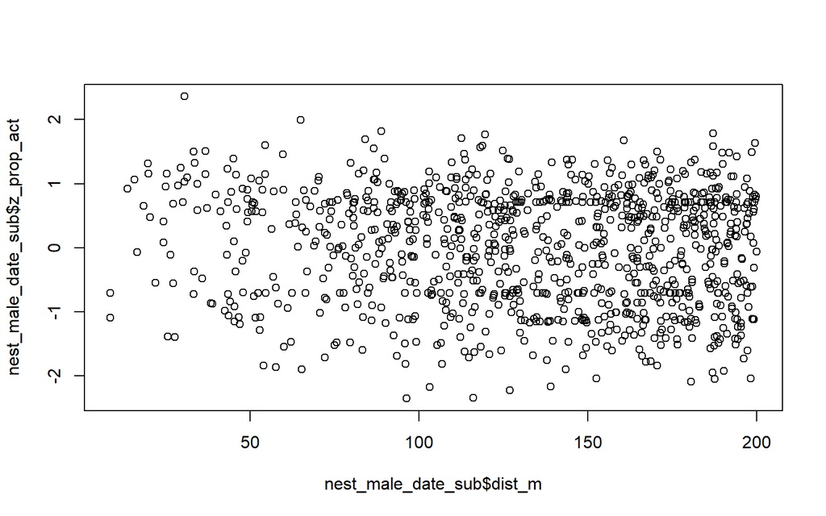

```r
plot(nest_male_date_sub$dist_m, nest_male_date_sub$z_prop_act)
```

```r
nest_male_m <- glmmTMB(success ~ scale(z_prop_act) +
                         (1|bird_ID) +
                         (1|nest),
                       data = nest_male_date_sub,
                       family = binomial())

summary(nest_male_m)
```

```
##  Family: binomial  ( logit )
## Formula:          success ~ scale(z_prop_act) + (1 | bird_ID) + (1 | nest)
## Data: nest_male_date_sub
##
##      AIC      BIC   logLik deviance df.resid
##      254      273     -123      246      987
##
## Random effects:
##
## Conditional model:
##  Groups  Name        Variance Std.Dev.
##  bird_ID (Intercept) 117      10.8
##  nest    (Intercept) 114      10.7
## Number of obs: 991, groups:  bird_ID, 62; nest, 40
##
## Conditional model:
##                   Estimate Std. Error z value Pr(>|z|)
## (Intercept)        -20.179      4.671   -4.32 0.000016 ***
## scale(z_prop_act)    0.734      0.311    2.36    0.018 *
## ---
## Signif. codes:  0 '***' 0.001 '**' 0.01 '*' 0.05 '.' 0.1 ' ' 1
```

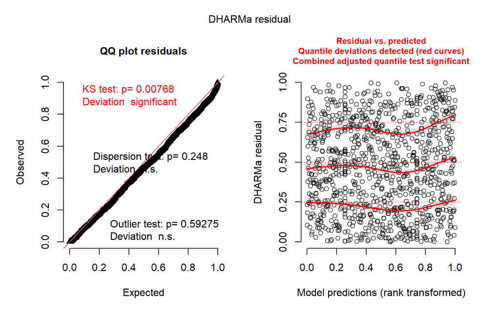

```r
simulationOutput <- simulateResiduals(fittedModel = nest_male_m, plot=F)
plot(simulationOutput)
```

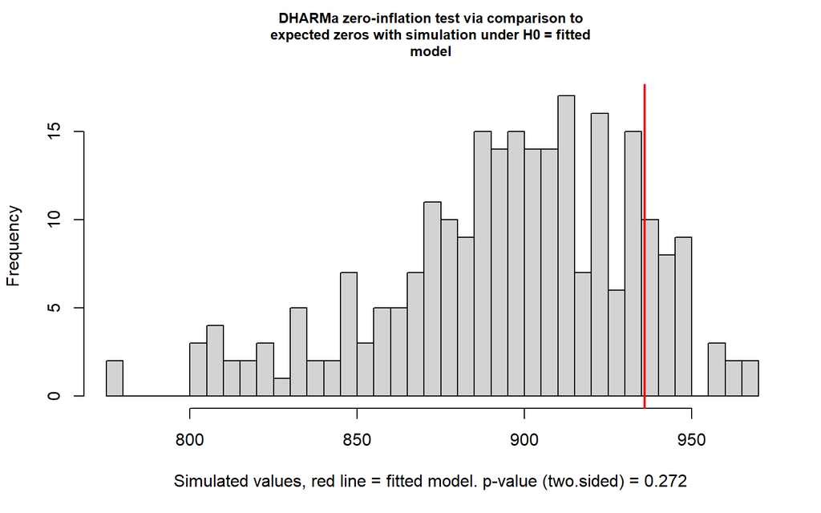

```
##
##  DHARMa zero-inflation test via comparison to expected zeros with
##  simulation under H0 = fitted model
##
## data:  simulationOutput
## ratioObsSim = 1, p-value = 0.3
## alternative hypothesis: two.sided
```

```r
testZeroInflation(simulationOutput)
```

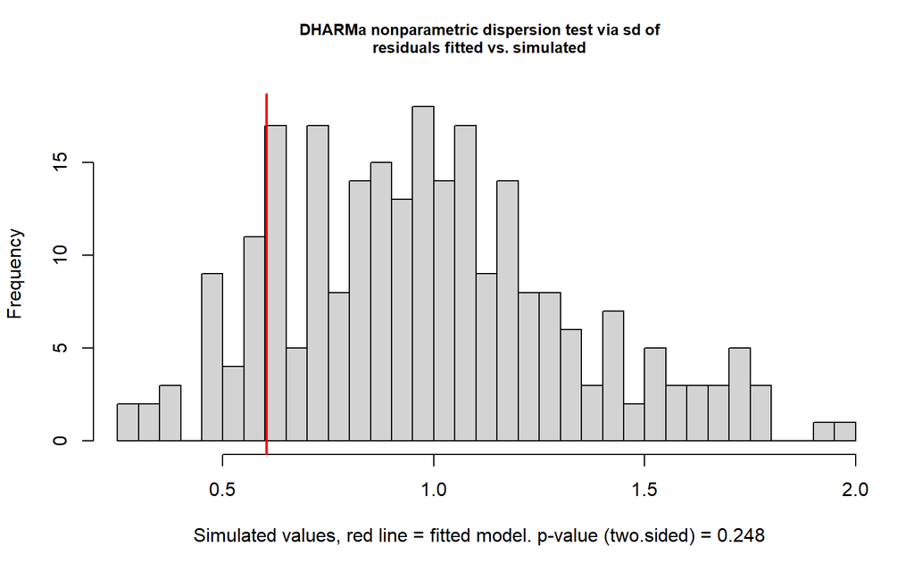

```
##
##  DHARMa nonparametric dispersion test via sd of residuals fitted vs.
##  simulated
##
## data:  simulationOutput
## dispersion = 0.6, p-value = 0.2
## alternative hypothesis: two.sided
```

```r
testDispersion(simulationOutput)
```

```r
nm_rel_effects <- confint(nest_male_m)
nm_rel_effects <- cbind(name=rownames(nm_rel_effects),
                        data.frame(nm_rel_effects,
                                   row.names=NULL)) %>%
  rename(`2.5`=`X2.5..`,
         `97.5`=`X97.5..`,
         estimate=Estimate) %>%
  mutate(effect_type="rel")
```

```r
if(save_tables==TRUE){
nest_m_flex <- as_flextable(nest_male_m)
save_as_docx(nest_m_flex,
             pr_section = sect_properties,
             path = glue("{output_path}/scaled_nest_male_model.docx"))
}
```

## Fig: Activity relative to competitors

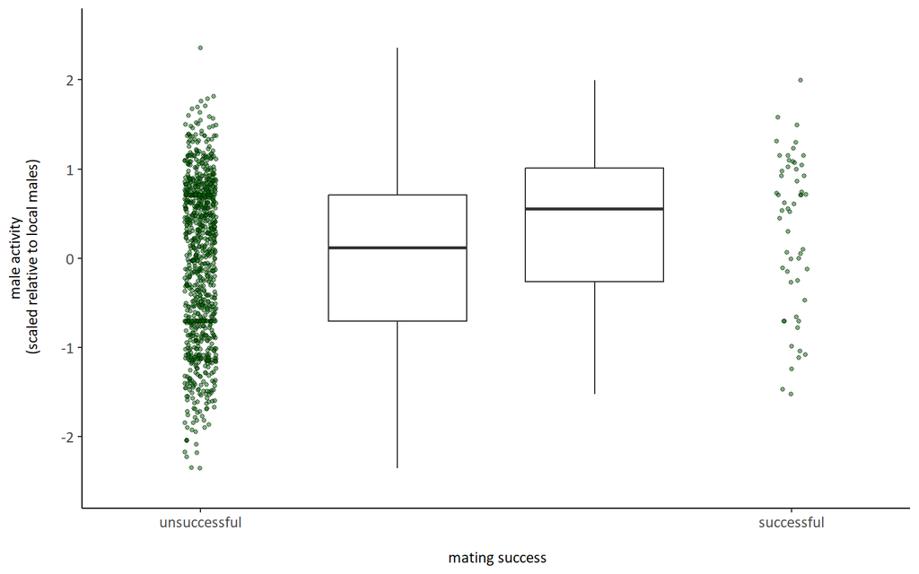

```r
nest_male_plotdat <- rbind(nest_male_date_sub %>% mutate(plot_type="box"),
                              nest_male_date_sub %>% mutate(plot_type="point"))

nest_male_plotdat$plot_factor <- factor(
  paste0("s", nest_male_plotdat$success, "-", nest_male_plotdat$plot_type),
  levels = c("s0-point", "s0-box", "s1-box", "s1-point"))

nest_male_boxplot <- ggplot() +
  theme_classic()+
    geom_point(data = nest_male_plotdat %>%
                 filter(plot_factor == "s0-point"),
               aes(x = plot_factor,
                   y = z_prop_act),
             size=small.point.size,
             alpha=point_alpha,
             shape=default_shape,
             fill=male_colour,
             position=position_jitter(w=0.08, h=0, seed = 1),
             ) +
  geom_boxplot(data = nest_male_plotdat %>%
                 filter(plot_factor == "s0-box"),
               aes(x = plot_factor,
                   y = z_prop_act),
               outlier.shape=default_shape,
               fill="white",
               width=0.7) +
  geom_boxplot(data = nest_male_plotdat %>%
                 filter(plot_factor == "s1-box"),
               aes(x = plot_factor,
                   y = z_prop_act),
               outlier.shape=default_shape,
               fill="white",
               width=0.7)+
  geom_point(data = nest_male_plotdat %>%
                 filter(plot_factor == "s1-point"),
               aes(x = plot_factor,
                   y = z_prop_act),
             size=small.point.size,
             alpha=point_alpha,
             shape=default_shape,
             fill=male_colour,
             position=position_jitter(w=0.08, h=0, seed = 1),
             ) +
  coord_cartesian(ylim=c(-2.8,2.8))+
  scale_y_continuous(breaks=c(seq(-2,2,by=1)),
                     expand=c(0,0))+
  scale_x_discrete(breaks = c("s0-point", "s1-point"),
                   labels = c("unsuccessful", "successful"))+
  xlab("\n mating success")+
  ylab("male activity\n (scaled relative to local males)\n")+
  theme(text=element_text(family=font.family),
        axis.title = element_text(size=axis.heading.size),
        axis.text = element_text(size=label.size),
        legend.title = element_text(size=legend.heading.size),
        legend.text = element_text(size=label.size),
        legend.position="right",
        legend.justification="top",
        legend.background = element_blank(),
        legend.box.background = element_rect(colour = "grey"))

nest_male_boxplot
```

```r
if(save_plots==TRUE){
ggsave(plot=nest_male_boxplot,
       filename='figure4-relative-male-activity.jpg',
       path=output_path,
       width=14,
       height=7,
       units="cm",
       dpi=300)
}
```

# Q: How repeatable is activity during the fertile period?

```r
repeat_lme <- lmer(prop_activity ~ (1|bird_ID),
                      data = daily_activity %>% filter(breeding_stage=="fertile"))

summary(repeat_lme)
```

```
## Linear mixed model fit by REML ['lmerMod']
## Formula: prop_activity ~ (1 | bird_ID)
##    Data: daily_activity %>% filter(breeding_stage == "fertile")
##
## REML criterion at convergence: -313
##
## Scaled residuals:
##     Min      1Q  Median      3Q     Max
## -2.7510 -0.5959 -0.0531  0.5941  2.5074
##
## Random effects:
##  Groups   Name        Variance Std.Dev.
##  bird_ID  (Intercept) 0.0169   0.130
##  Residual             0.0260   0.161
## Number of obs: 555, groups:  bird_ID, 81
##
## Fixed effects:
##             Estimate Std. Error t value
## (Intercept)   0.6055     0.0162    37.4
```

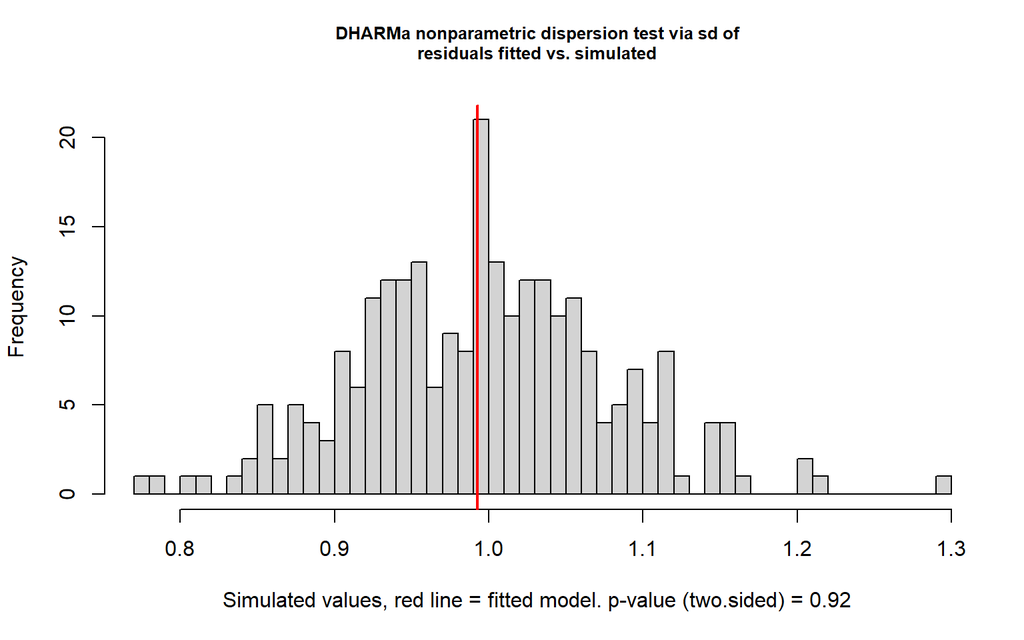

```
##
##  DHARMa nonparametric dispersion test via sd of residuals fitted vs.
##  simulated
##
## data:  simulationOutput
## dispersion = 1, p-value = 0.9
## alternative hypothesis: two.sided
```

```r
simulationOutput <- simulateResiduals(fittedModel = repeat_lme, plot=F)
testDispersion(simulationOutput)
```

```r
# Get variance
vc = VarCorr(repeat_lme)
withingroup_var=attr(vc, 'sc')[1]^2
betweengroup_var=attr(vc$bird_ID, 'stddev')[1]^2

# repeatability
R = betweengroup_var/(betweengroup_var+withingroup_var)
R
```

```
## (Intercept)
##       0.394
```

Within-individual repeatability of daily activity during the fertile phase was R = 0.394.